# Construct Non-Hierarchical P/NBD Model for Long Timeframe Synthetic Data

Author

Mick Cooney mickcooney@gmail.com

Published

November 11, 2023

In this workbook we construct the non-hierarchical P/NBD models on the synthetic data with the longer timeframe.

# 1 Load and Construct Datasets

## 1.1 Load Long-Timeframe Synthetic Transaction Data

```r
customer_cohortdata_tbl <- read_rds("data/longsynth_customer_cohort_data_tbl.rds")
customer_cohortdata_tbl |> glimpse()
```

```
Rows: 5,000
Columns: 5
$ customer_id     <chr> "LFC201001_0001", "LFC201001_0002", "LFC201001_0003", …
$ cohort_qtr      <chr> "2010 Q1", "2010 Q1", "2010 Q1", "2010 Q1", "2010 Q1",…
$ cohort_ym       <chr> "2010 01", "2010 01", "2010 01", "2010 01", "2010 01",…
$ first_tnx_date  <dttm> 2010-01-01 16:16:30, 2010-01-03 16:32:54, 2010-01-04 …
$ total_tnx_count <int> 12, 1, 1, 2, 2, 3, 2, 7, 5, 5, 4, 8, 1, 1, 1, 31, 1, 1…
```

```r
customer_transactions_tbl <- read_rds("data/longsynth_transaction_data_tbl.rds")
customer_transactions_tbl |> glimpse()
```

```
Rows: 42,244
Columns: 7
$ customer_id   <chr> "LFC201001_0001", "LFC201001_0002", "LFC201001_0003", "L…
$ tnx_timestamp <dttm> 2010-01-01 16:16:30, 2010-01-03 16:32:54, 2010-01-04 22…
$ tnx_dow       <fct> Fri, Sun, Mon, Tue, Wed, Thu, Sun, Sun, Mon, Mon, Tue, W…
$ tnx_month     <fct> Jan, Jan, Jan, Jan, Jan, Jan, Jan, Jan, Jan, Jan, Jan, J…
$ tnx_week      <chr> "00", "00", "01", "01", "01", "01", "01", "01", "02", "0…
$ invoice_id    <chr> "T20100101-0001", "T20100103-0001", "T20100104-0001", "T…
$ tnx_amount    <dbl> 160.87, 1.30, 96.11, 813.07, 85.58, 35.07, 12.23, 70.48,…
```

```r
customer_subset_id <- read_rds("data/longsynth_customer_subset_ids.rds")
customer_subset_id |> glimpse()
```

```
 Factor w/ 5000 levels "LFC201001_0001",..: 2 8 10 14 16 17 27 30 33 35 ...
```

We re-produce the visualisation of the transaction times we used in previous workbooks.

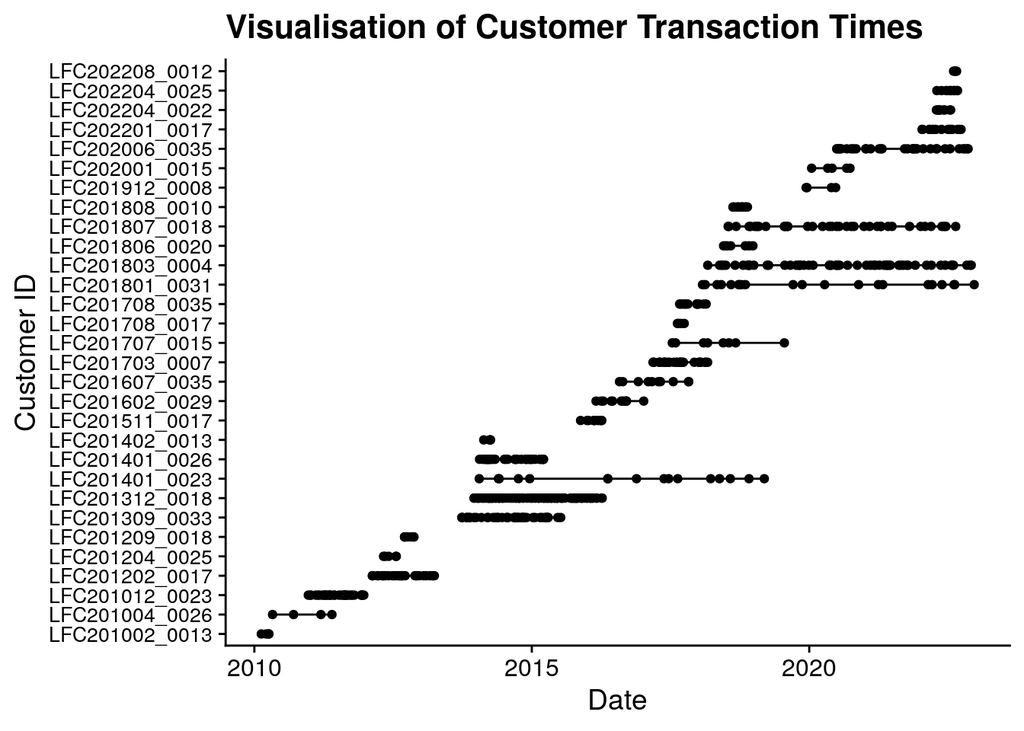

```r
plot_tbl <- customer_transactions_tbl |>
  group_nest(customer_id, .key = "cust_data") |>
  filter(map_int(cust_data, nrow) > 3) |>
  slice_sample(n = 30) |>
  unnest(cust_data)

ggplot(plot_tbl, aes(x = tnx_timestamp, y = customer_id)) +
  geom_line() +
  geom_point() +
  labs(
      x = "Date",
      y = "Customer ID",
      title = "Visualisation of Customer Transaction Times"
    ) +
  theme(axis.text.y = element_text(size = 10))
```

## 1.2 Load Derived Data

```r
obs_fitdata_tbl   <- read_rds("data/longsynth_obs_fitdata_tbl.rds")
obs_validdata_tbl <- read_rds("data/longsynth_obs_validdata_tbl.rds")

customer_fit_stats_tbl <- obs_fitdata_tbl |>
  rename(x = tnx_count)
```

## 1.3 Load Subset Data

We also want to construct our data subsets for the purposes of speeding up our valuations.

```r
customer_fit_subset_tbl <- obs_fitdata_tbl |>
  filter(customer_id %in% customer_subset_id)

customer_fit_subset_tbl |> glimpse()
```

```
Rows: 1,000
Columns: 6
$ customer_id    <fct> LFC201001_0002, LFC201001_0008, LFC201001_0010, LFC2010…
$ first_tnx_date <dttm> 2010-01-03 16:32:54, 2010-01-10 08:26:52, 2010-01-11 2…
$ last_tnx_date  <dttm> 2010-01-03 16:32:54, 2010-06-24 02:01:46, 2010-02-28 0…
$ tnx_count      <dbl> 0, 6, 4, 30, 0, 0, 4, 2, 2, 11, 0, 6, 3, 1, 1, 1, 0, 4,…
$ t_x            <dbl> 0.0000000, 23.5332238, 6.7394202, 30.6992466, 0.0000000…
$ T_cal          <dbl> 625.7586, 624.8069, 624.5765, 624.2573, 624.1894, 624.0…
```

```r
customer_valid_subset_tbl <- obs_validdata_tbl |>
  filter(customer_id %in% customer_subset_id)

customer_valid_subset_tbl |> glimpse()
```

```
Rows: 1,000
Columns: 3
$ customer_id       <fct> LFC201001_0002, LFC201001_0008, LFC201001_0010, LFC2…
$ tnx_count         <dbl> 0, 0, 0, 0, 0, 0, 0, 0, 0, 0, 0, 0, 0, 0, 0, 0, 0, 0…
$ tnx_last_interval <dbl> NA, NA, NA, NA, NA, NA, NA, NA, NA, NA, NA, NA, NA, …
```

We now use these datasets to set the start and end dates for our various validation methods.

```r
dates_lst <- read_rds("data/longsynth_simulation_dates.rds")

use_fit_start_date <- dates_lst$use_fit_start_date
use_fit_end_date   <- dates_lst$use_fit_end_date

use_valid_start_date <- dates_lst$use_valid_start_date
use_valid_end_date   <- dates_lst$use_valid_end_date
```

Before we start on that, we set a few parameters for the workbook to organise our Stan code.

```r
stan_modeldir <- "stan_models"
stan_codedir  <-   "stan_code"
```

# 2 Fit First P/NBD Model

## 2.1 Compile and Fit Stan Model

We now compile this model using `CmdStanR`.

```r
pnbd_fixed_stanmodel <- cmdstan_model(
  "stan_code/pnbd_fixed.stan",
  include_paths =   stan_codedir,
  pedantic      =           TRUE,
  dir           =  stan_modeldir
  )
```

We then use this compiled model with our data to produce a fit of the data.

```r
stan_modelname <- "pnbd_long_fixed1"
stanfit_prefix <- str_c("fit_", stan_modelname)
stanfit_seed   <- stanfit_seed + 1

stanfit_object_file <- glue("data/{stanfit_prefix}_stanfit.rds")


stan_data_lst <- customer_fit_stats_tbl |>
  select(customer_id, x, t_x, T_cal) |>
  compose_data(
    lambda_mn = 0.25,
    lambda_cv = 1.00,

    mu_mn     = 0.10,
    mu_cv     = 1.00,
    )

if(!file_exists(stanfit_object_file)) {
  pnbd_long_fixed1_stanfit <- pnbd_fixed_stanmodel$sample(
    data            =                stan_data_lst,
    chains          =                            4,
    iter_warmup     =                          500,
    iter_sampling   =                          500,
    seed            =                 stanfit_seed,
    save_warmup     =                         TRUE,
    output_dir      =                stan_modeldir,
    output_basename =               stanfit_prefix,
    )

  pnbd_long_fixed1_stanfit$save_object(stanfit_object_file, compress = "gzip")

} else {
  pnbd_long_fixed1_stanfit <- read_rds(stanfit_object_file)
}

pnbd_long_fixed1_stanfit$summary()
```

```
# A tibble: 13,726 × 10
   variable       mean   median      sd     mad       q5      q95  rhat ess_bulk
   <chr>         <num>    <num>   <num>   <num>    <num>    <num> <num>    <num>
 1 lp__       -1.04e+5 -1.04e+5 71.3    7.26e+1 -1.04e+5 -1.04e+5 1.01      722.
 2 lambda[1]   3.50e-2  3.40e-2  0.0101 9.70e-3  2.04e-2  5.33e-2 1.00     2220.
 3 lambda[2]   1.38e-1  8.63e-2  0.157  9.59e-2  6.21e-3  4.56e-1 1.00     1649.
 4 lambda[3]   1.44e-1  8.92e-2  0.165  9.83e-2  5.78e-3  4.49e-1 1.00     2475.
 5 lambda[4]   2.33e-1  1.84e-1  0.189  1.47e-1  3.50e-2  5.92e-1 1.01     1397.
 6 lambda[5]   2.63e-1  2.05e-1  0.211  1.65e-1  3.93e-2  6.98e-1 1.00     1694.
 7 lambda[6]   1.94e-1  1.68e-1  0.123  1.06e-1  4.78e-2  4.35e-1 1.00     2594.
 8 lambda[7]   2.06e-1  1.64e-1  0.167  1.34e-1  2.84e-2  5.28e-1 0.999    2138.
 9 lambda[8]   2.22e-1  2.11e-1  0.0859 8.53e-2  1.03e-1  3.74e-1 1.00     2055.
10 lambda[9]   2.39e-1  2.18e-1  0.118  1.06e-1  8.76e-2  4.59e-1 1.00     1821.
# ℹ 13,716 more rows
# ℹ 1 more variable: ess_tail <num>
```

We have some basic HMC-based validity statistics we can check.

```r
pnbd_long_fixed1_stanfit$cmdstan_diagnose()
```

```
Processing csv files: /home/rstudio/btydwork/stan_models/fit_pnbd_long_fixed1-1.csvWarning: non-fatal error reading adaptation data
, /home/rstudio/btydwork/stan_models/fit_pnbd_long_fixed1-2.csvWarning: non-fatal error reading adaptation data
, /home/rstudio/btydwork/stan_models/fit_pnbd_long_fixed1-3.csvWarning: non-fatal error reading adaptation data
, /home/rstudio/btydwork/stan_models/fit_pnbd_long_fixed1-4.csvWarning: non-fatal error reading adaptation data


Checking sampler transitions treedepth.
Treedepth satisfactory for all transitions.

Checking sampler transitions for divergences.
No divergent transitions found.

Checking E-BFMI - sampler transitions HMC potential energy.
E-BFMI satisfactory.

Effective sample size satisfactory.

Split R-hat values satisfactory all parameters.

Processing complete, no problems detected.
```

## 2.2 Visual Diagnostics of the Sample Validity

Now that we have a sample from the posterior distribution we need to create a few different visualisations of the diagnostics.

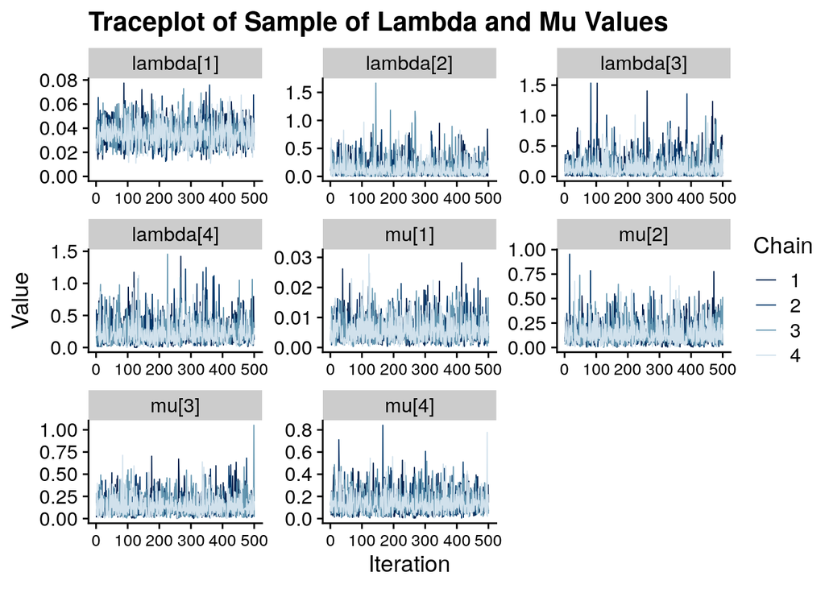

```r
parameter_subset <- c(
  "lambda[1]", "lambda[2]", "lambda[3]", "lambda[4]",
  "mu[1]",     "mu[2]",     "mu[3]",     "mu[4]"
  )

pnbd_long_fixed1_stanfit$draws(inc_warmup = FALSE) |>
  mcmc_trace(pars = parameter_subset) +
  expand_limits(y = 0) +
  labs(
    x = "Iteration",
    y = "Value",
    title = "Traceplot of Sample of Lambda and Mu Values"
    ) +
  theme(axis.text.x = element_text(size = 10))
```

We also check $N_{eff}$ as a quick diagnostic of the fit.

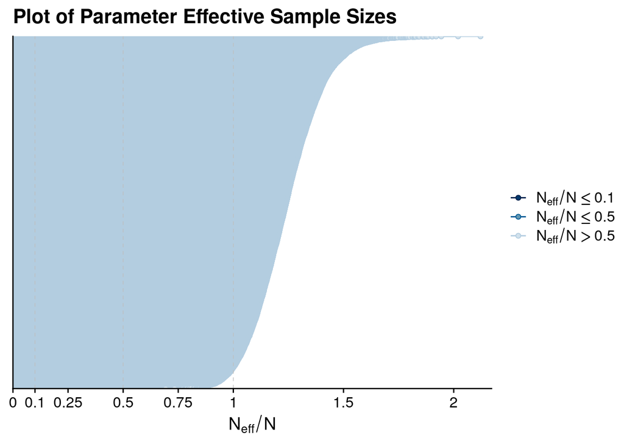

```r
pnbd_long_fixed1_stanfit |>
  neff_ratio(pars = c("lambda", "mu")) |>
  mcmc_neff() +
    ggtitle("Plot of Parameter Effective Sample Sizes")
```

## 2.3 Assess the Model

As we intend to run the same logic to assess each of our models, we have combined all this logic into a single function `run_model_assessment`, to run the simulations and combine the datasets.

```r
pnbd_stanfit <- pnbd_long_fixed1_stanfit |>
  recover_types(customer_fit_stats_tbl)

pnbd_long_fixed1_assess_data_lst <- run_model_assessment(
  model_stanfit       = pnbd_stanfit,
  insample_tbl        = customer_fit_subset_tbl,
  fit_label           = "pnbd_long_fixed1",
  fit_end_dttm        = use_fit_end_date     |> as.POSIXct(),
  valid_start_dttm    = use_valid_start_date |> as.POSIXct(),
  valid_end_dttm      = use_valid_end_date   |> as.POSIXct(),
  precompute_rootdir  = "precompute",
  data_dir            = "data",
  summary_include_tnx = FALSE,
  sim_seed            = 4210
  )

pnbd_long_fixed1_assess_data_lst |> glimpse()
```

```
List of 5
 $ model_fit_index_filepath     : 'glue' chr "data/pnbd_long_fixed1_assess_fit_index_tbl.rds"
 $ model_valid_index_filepath   : 'glue' chr "data/pnbd_long_fixed1_assess_valid_index_tbl.rds"
 $ model_simstats_filepath      : 'glue' chr "data/pnbd_long_fixed1_assess_model_simstats_tbl.rds"
 $ model_fit_simstats_filepath  : 'glue' chr "data/pnbd_long_fixed1_assess_fit_simstats_tbl.rds"
 $ model_valid_simstats_filepath: 'glue' chr "data/pnbd_long_fixed1_assess_valid_simstats_tbl.rds"
```

### 2.3.1 Check In-Sample Data Validation

We first check the model against the in-sample data.

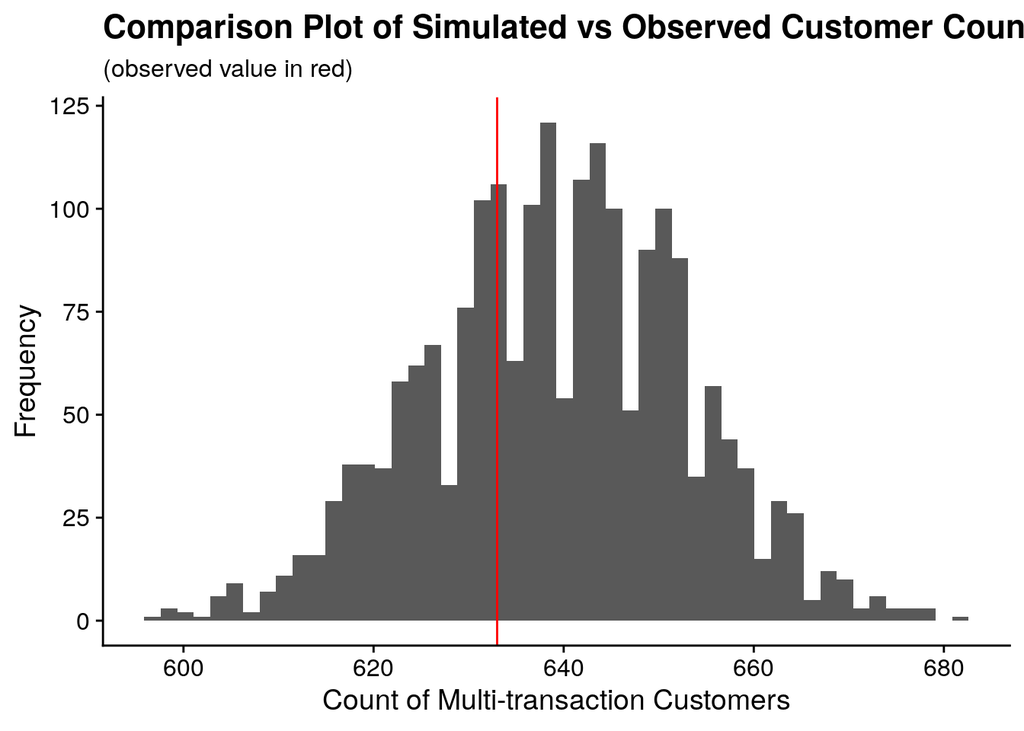

```r
simdata_tbl <- pnbd_long_fixed1_assess_data_lst |>
  use_series(model_fit_simstats_filepath) |>
  read_rds()

insample_plots_lst <- create_model_assessment_plots(
  obsdata_tbl = customer_fit_subset_tbl,
  simdata_tbl = simdata_tbl
  )

insample_plots_lst$multi_plot |> print()
```

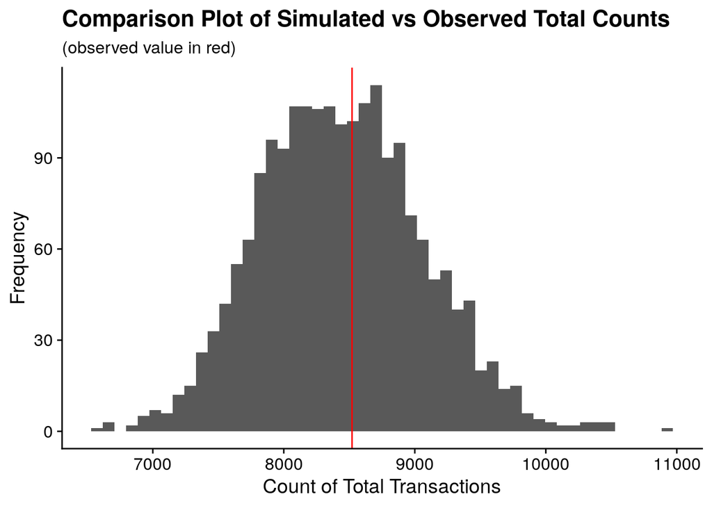

```r
insample_plots_lst$total_plot |> print()
```

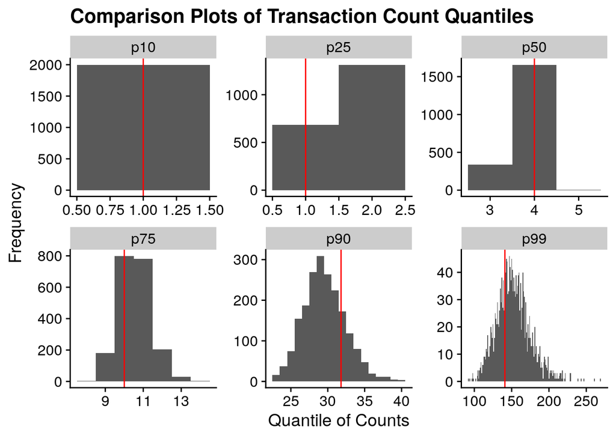

```r
insample_plots_lst$quant_plot |> print()
```

This fit looks reasonable and appears to capture most of the aspects of the data used to fit it. Given that this is a synthetic dataset, this is not surprising, but at least we appreciate that our model is valid.

### 2.3.2 Check Out-of-Sample Data Validation

We now repeat for the out-of-sample data.

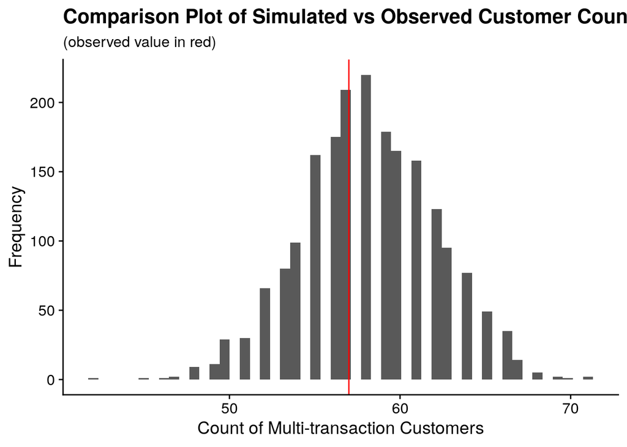

```r
simdata_tbl <- pnbd_long_fixed1_assess_data_lst |>
  use_series(model_valid_simstats_filepath) |>
  read_rds()

outsample_plots_lst <- create_model_assessment_plots(
  obsdata_tbl = customer_valid_subset_tbl,
  simdata_tbl = simdata_tbl
  )

outsample_plots_lst$multi_plot |> print()
```

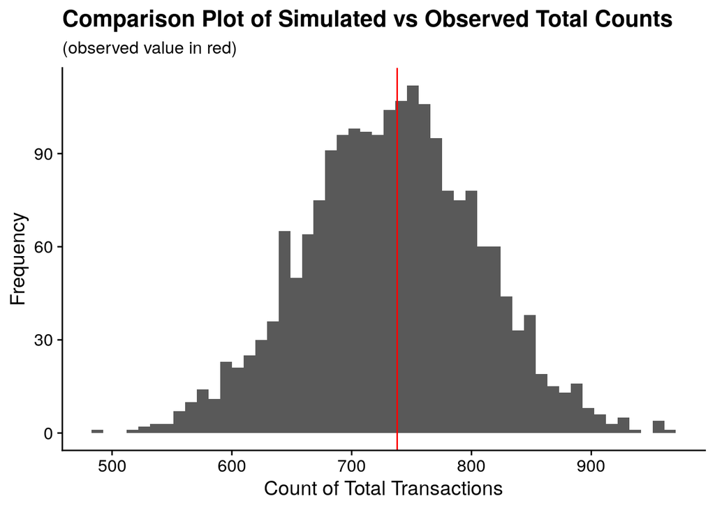

```r
outsample_plots_lst$total_plot |> print()
```

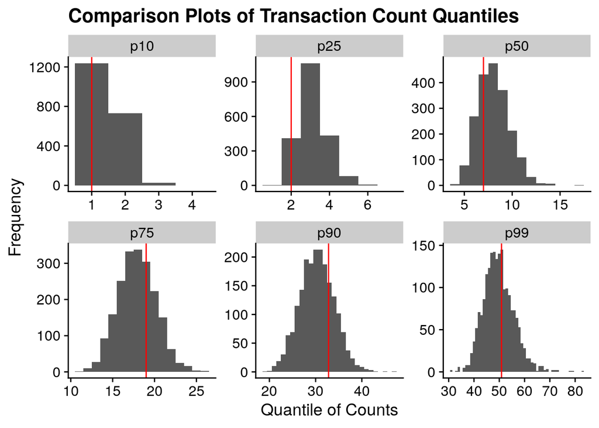

```r
outsample_plots_lst$quant_plot |> print()
```

As for our long time frame data, overall our model is working well.

# 3 Fit Alternate Prior Model.

We want to try an alternate prior model with a smaller co-efficient of variation to see what impact it has on our procedures.

```r
stan_modelname <- "pnbd_long_fixed2"
stanfit_prefix <- str_c("fit_", stan_modelname)
stanfit_seed   <- stanfit_seed + 1

stanfit_object_file <- glue("data/{stanfit_prefix}_stanfit.rds")


stan_data_lst <- customer_fit_stats_tbl |>
  select(customer_id, x, t_x, T_cal) |>
  compose_data(
    lambda_mn = 0.25,
    lambda_cv = 0.50,

    mu_mn     = 0.10,
    mu_cv     = 0.50,
    )


if(!file_exists(stanfit_object_file)) {
  pnbd_long_fixed2_stanfit <- pnbd_fixed_stanmodel$sample(
    data            =                stan_data_lst,
    chains          =                            4,
    iter_warmup     =                          500,
    iter_sampling   =                          500,
    seed            =                 stanfit_seed,
    save_warmup     =                         TRUE,
    output_dir      =                stan_modeldir,
    output_basename =               stanfit_prefix,
    )

  pnbd_long_fixed2_stanfit$save_object(stanfit_object_file, compress = "gzip")

} else {
  pnbd_long_fixed2_stanfit <- read_rds(stanfit_object_file)
}

pnbd_long_fixed2_stanfit$summary()
```

```
# A tibble: 13,726 × 10
   variable       mean   median      sd     mad       q5      q95  rhat ess_bulk
   <chr>         <num>    <num>   <num>   <num>    <num>    <num> <num>    <num>
 1 lp__       -1.85e+5 -1.85e+5 69.9    71.2    -1.85e+5 -1.85e+5  1.01     651.
 2 lambda[1]   4.32e-2  4.22e-2  0.0112  0.0113  2.61e-2  6.37e-2  1.00    3137.
 3 lambda[2]   2.14e-1  1.93e-1  0.113   0.101   6.63e-2  4.22e-1  1.01    3458.
 4 lambda[3]   2.11e-1  1.88e-1  0.116   0.105   6.53e-2  4.33e-1  1.00    4832.
 5 lambda[4]   2.42e-1  2.22e-1  0.119   0.111   8.73e-2  4.69e-1  1.00    2799.
 6 lambda[5]   2.48e-1  2.32e-1  0.115   0.113   9.38e-2  4.67e-1  1.00    4278.
 7 lambda[6]   2.17e-1  2.07e-1  0.0897  0.0899  9.39e-2  3.80e-1  1.00    3186.
 8 lambda[7]   2.29e-1  2.14e-1  0.107   0.0999  8.75e-2  4.25e-1  1.00    3205.
 9 lambda[8]   2.34e-1  2.27e-1  0.0750  0.0711  1.24e-1  3.75e-1  1.00    4096.
10 lambda[9]   2.43e-1  2.34e-1  0.0919  0.0913  1.15e-1  4.04e-1  1.00    3512.
# ℹ 13,716 more rows
# ℹ 1 more variable: ess_tail <num>
```

We have some basic HMC-based validity statistics we can check.

```r
pnbd_long_fixed2_stanfit$cmdstan_diagnose()
```

```
Processing csv files: /home/rstudio/btydwork/stan_models/fit_pnbd_long_fixed2-1.csvWarning: non-fatal error reading adaptation data
, /home/rstudio/btydwork/stan_models/fit_pnbd_long_fixed2-2.csvWarning: non-fatal error reading adaptation data
, /home/rstudio/btydwork/stan_models/fit_pnbd_long_fixed2-3.csvWarning: non-fatal error reading adaptation data
, /home/rstudio/btydwork/stan_models/fit_pnbd_long_fixed2-4.csvWarning: non-fatal error reading adaptation data


Checking sampler transitions treedepth.
Treedepth satisfactory for all transitions.

Checking sampler transitions for divergences.
No divergent transitions found.

Checking E-BFMI - sampler transitions HMC potential energy.
E-BFMI satisfactory.

Effective sample size satisfactory.

Split R-hat values satisfactory all parameters.

Processing complete, no problems detected.
```

## 3.1 Visual Diagnostics of the Sample Validity

Now that we have a sample from the posterior distribution we need to create a few different visualisations of the diagnostics.

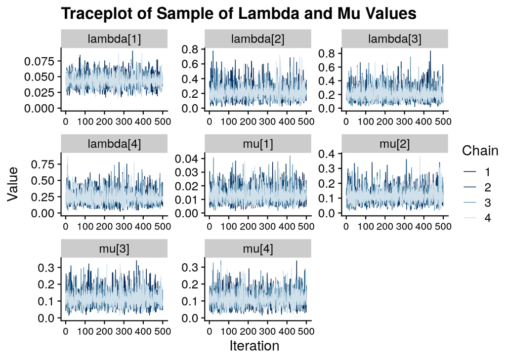

```r
parameter_subset <- c(
  "lambda[1]", "lambda[2]", "lambda[3]", "lambda[4]",
  "mu[1]",     "mu[2]",     "mu[3]",     "mu[4]"
  )

pnbd_long_fixed2_stanfit$draws(inc_warmup = FALSE) |>
  mcmc_trace(pars = parameter_subset) +
  expand_limits(y = 0) +
  labs(
    x = "Iteration",
    y = "Value",
    title = "Traceplot of Sample of Lambda and Mu Values"
    ) +
  theme(axis.text.x = element_text(size = 10))
```

We want to check the $N_{eff}$ statistics also.

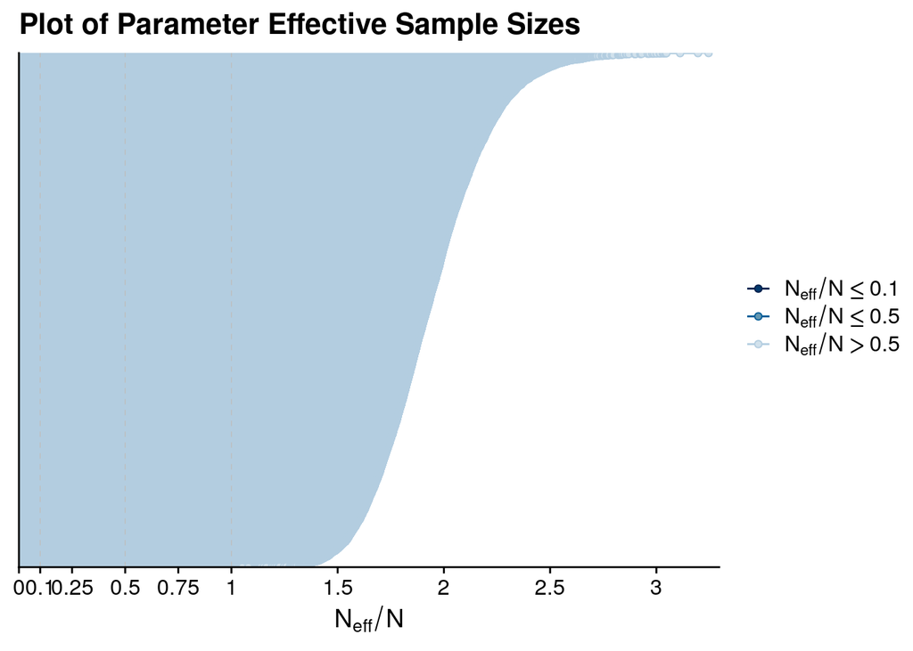

```r
pnbd_long_fixed2_stanfit |>
  neff_ratio(pars = c("lambda", "mu")) |>
  mcmc_neff() +
    ggtitle("Plot of Parameter Effective Sample Sizes")
```

## 3.2 Assess the Model

As we intend to run the same logic to assess each of our models, we have combined all this logic into a single function `run_model_assessment`, to run the simulations and combine the datasets.

```r
pnbd_stanfit <- pnbd_long_fixed2_stanfit |>
  recover_types(customer_fit_stats_tbl)

pnbd_long_fixed2_assess_data_lst <- run_model_assessment(
  model_stanfit       = pnbd_stanfit,
  insample_tbl        = customer_fit_subset_tbl,
  fit_label           = "pnbd_long_fixed2",
  fit_end_dttm        = use_fit_end_date     |> as.POSIXct(),
  valid_start_dttm    = use_valid_start_date |> as.POSIXct(),
  valid_end_dttm      = use_valid_end_date   |> as.POSIXct(),
  precompute_rootdir  = "precompute",
  data_dir            = "data",
  summary_include_tnx = FALSE,
  sim_seed            = 4220
  )

pnbd_long_fixed2_assess_data_lst |> glimpse()
```

```
List of 5
 $ model_fit_index_filepath     : 'glue' chr "data/pnbd_long_fixed2_assess_fit_index_tbl.rds"
 $ model_valid_index_filepath   : 'glue' chr "data/pnbd_long_fixed2_assess_valid_index_tbl.rds"
 $ model_simstats_filepath      : 'glue' chr "data/pnbd_long_fixed2_assess_model_simstats_tbl.rds"
 $ model_fit_simstats_filepath  : 'glue' chr "data/pnbd_long_fixed2_assess_fit_simstats_tbl.rds"
 $ model_valid_simstats_filepath: 'glue' chr "data/pnbd_long_fixed2_assess_valid_simstats_tbl.rds"
```

### 3.2.1 Check In-Sample Data Validation

We first check the model against the in-sample data.

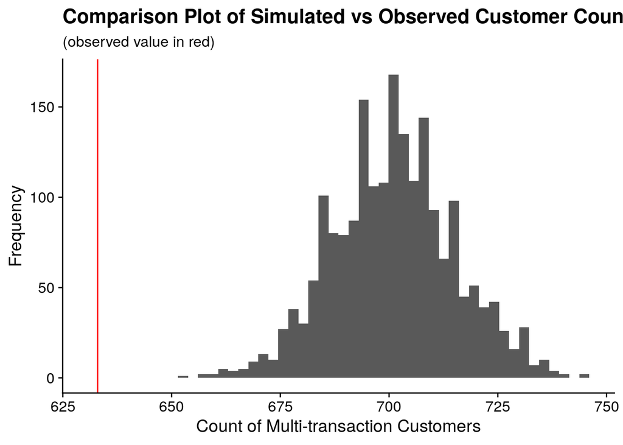

```r
simdata_tbl <- pnbd_long_fixed2_assess_data_lst |>
  use_series(model_fit_simstats_filepath) |>
  read_rds()

insample_plots_lst <- create_model_assessment_plots(
  obsdata_tbl = customer_fit_subset_tbl,
  simdata_tbl = simdata_tbl
  )

insample_plots_lst$multi_plot |> print()
```

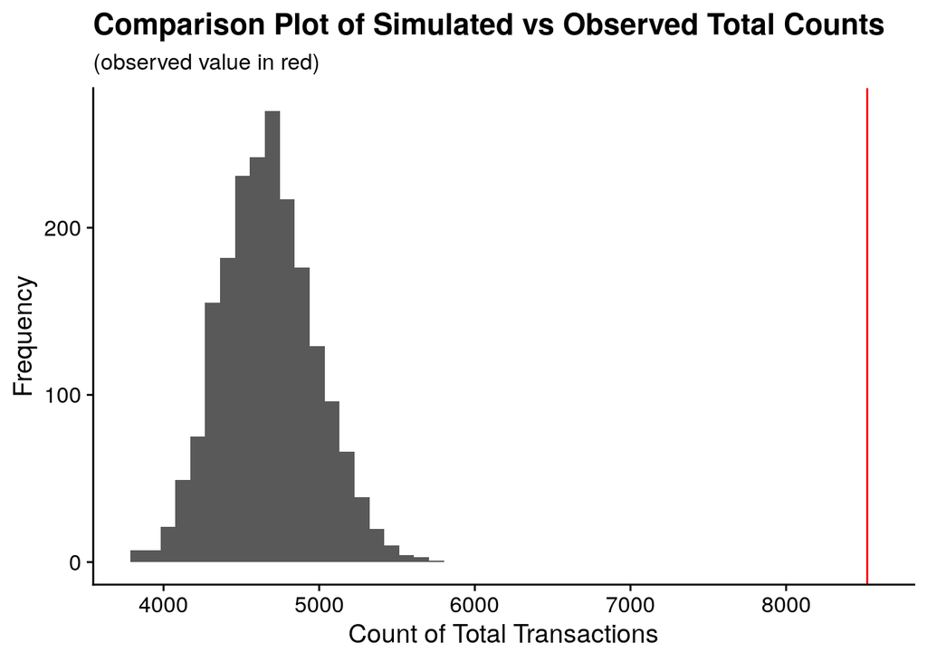

```r
insample_plots_lst$total_plot |> print()
```

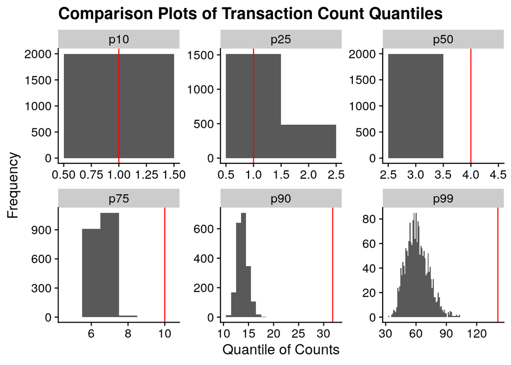

```r
insample_plots_lst$quant_plot |> print()
```

### 3.2.2 Check Out-of-Sample Data Validation

We now repeat for the out-of-sample data.

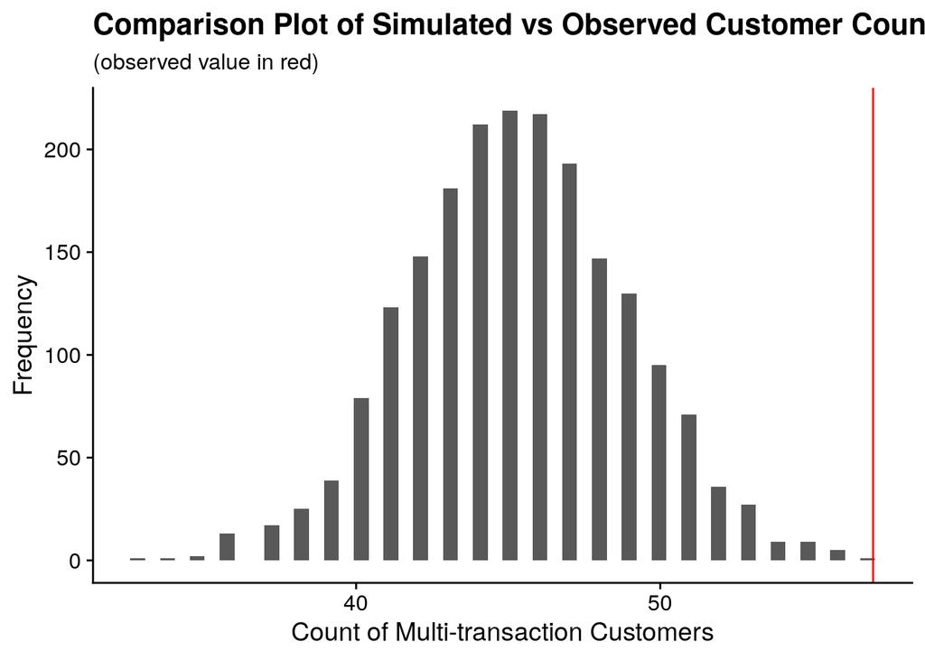

```r
simdata_tbl <- pnbd_long_fixed2_assess_data_lst |>
  use_series(model_valid_simstats_filepath) |>
  read_rds()

outsample_plots_lst <- create_model_assessment_plots(
  obsdata_tbl = customer_valid_subset_tbl,
  simdata_tbl = simdata_tbl
  )

outsample_plots_lst$multi_plot |> print()
```

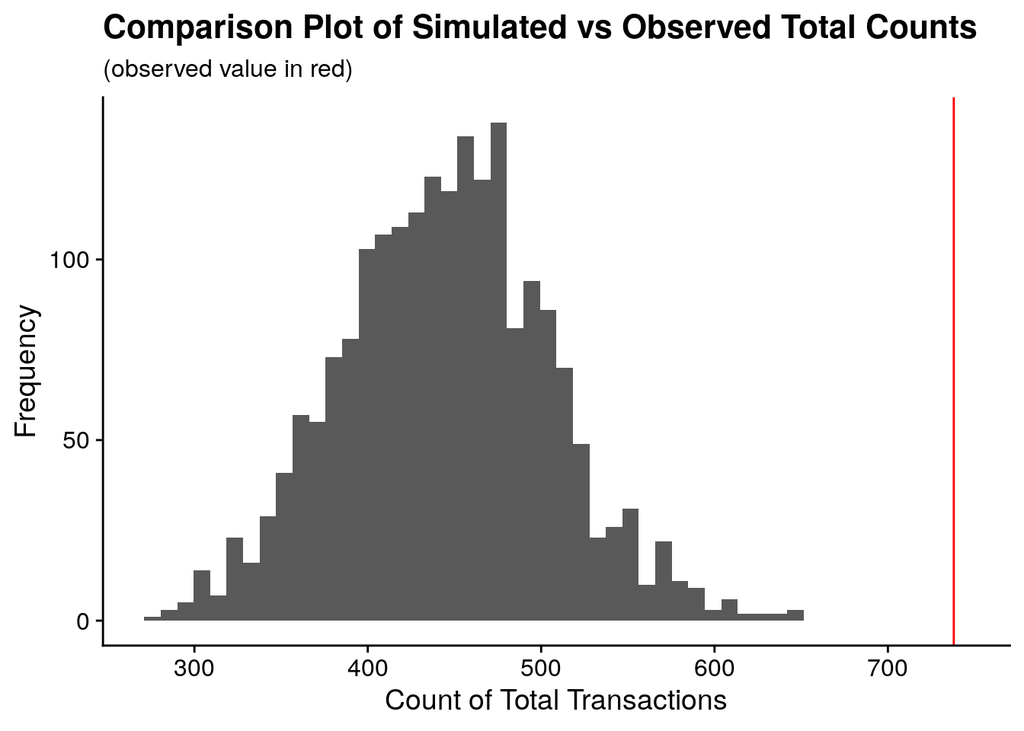

```r
outsample_plots_lst$total_plot |> print()
```

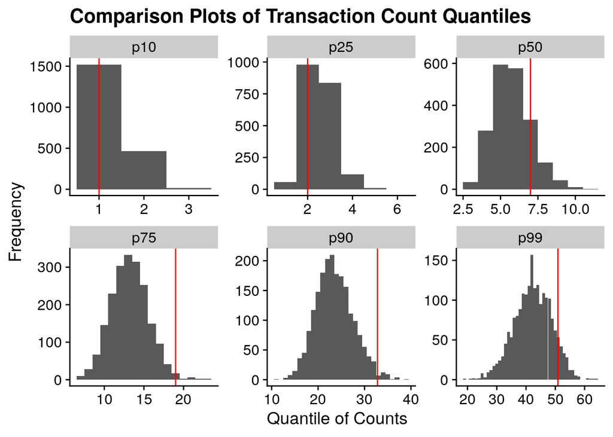

```r
outsample_plots_lst$quant_plot |> print()
```

# 4 Fit Tight-Lifetime Model

We now want to try a model where we use priors with a tighter coefficient of variation for lifetime but keep the CoV for transaction frequency.

```r
stan_modelname <- "pnbd_long_fixed3"
stanfit_prefix <- str_c("fit_", stan_modelname)
stanfit_seed   <- stanfit_seed + 1

stanfit_object_file <- glue("data/{stanfit_prefix}_stanfit.rds")


stan_data_lst <- customer_fit_stats_tbl |>
  select(customer_id, x, t_x, T_cal) |>
  compose_data(
    lambda_mn = 0.25,
    lambda_cv = 1.00,

    mu_mn     = 0.10,
    mu_cv     = 0.50,
    )

if(!file_exists(stanfit_object_file)) {
  pnbd_long_fixed3_stanfit <- pnbd_fixed_stanmodel$sample(
    data            =                stan_data_lst,
    chains          =                            4,
    iter_warmup     =                          500,
    iter_sampling   =                          500,
    seed            =                 stanfit_seed,
    save_warmup     =                         TRUE,
    output_dir      =                stan_modeldir,
    output_basename =               stanfit_prefix,
    )

  pnbd_long_fixed3_stanfit$save_object(stanfit_object_file, compress = "gzip")

} else {
  pnbd_long_fixed3_stanfit <- read_rds(stanfit_object_file)
}

pnbd_long_fixed3_stanfit$summary()
```

```
# A tibble: 13,726 × 10
   variable       mean   median      sd     mad       q5      q95  rhat ess_bulk
   <chr>         <num>    <num>   <num>   <num>    <num>    <num> <num>    <num>
 1 lp__       -1.51e+5 -1.51e+5 73.1    75.6    -1.51e+5 -1.51e+5  1.00     673.
 2 lambda[1]   3.56e-2  3.45e-2  0.0106  0.0101  2.04e-2  5.47e-2  1.00    3183.
 3 lambda[2]   1.40e-1  8.20e-2  0.170   0.0926  5.44e-3  4.57e-1  1.00    2405.
 4 lambda[3]   1.44e-1  8.46e-2  0.170   0.0918  5.94e-3  4.79e-1  1.00    3007.
 5 lambda[4]   2.37e-1  1.89e-1  0.184   0.146   3.92e-2  6.07e-1  1.00    2936.
 6 lambda[5]   2.46e-1  1.95e-1  0.196   0.153   3.67e-2  6.21e-1  1.00    2856.
 7 lambda[6]   1.92e-1  1.67e-1  0.122   0.108   4.52e-2  4.28e-1  1.00    2682.
 8 lambda[7]   2.01e-1  1.61e-1  0.153   0.127   3.38e-2  4.86e-1  1.00    2826.
 9 lambda[8]   2.31e-1  2.19e-1  0.0934  0.0890  1.02e-1  4.04e-1  1.00    3395.
10 lambda[9]   2.37e-1  2.21e-1  0.107   0.103   9.15e-2  4.38e-1  1.00    2711.
# ℹ 13,716 more rows
# ℹ 1 more variable: ess_tail <num>
```

We have some basic HMC-based validity statistics we can check.

```r
pnbd_long_fixed3_stanfit$cmdstan_diagnose()
```

```
Processing csv files: /home/rstudio/btydwork/stan_models/fit_pnbd_long_fixed3-1.csvWarning: non-fatal error reading adaptation data
, /home/rstudio/btydwork/stan_models/fit_pnbd_long_fixed3-2.csvWarning: non-fatal error reading adaptation data
, /home/rstudio/btydwork/stan_models/fit_pnbd_long_fixed3-3.csvWarning: non-fatal error reading adaptation data
, /home/rstudio/btydwork/stan_models/fit_pnbd_long_fixed3-4.csvWarning: non-fatal error reading adaptation data


Checking sampler transitions treedepth.
Treedepth satisfactory for all transitions.

Checking sampler transitions for divergences.
No divergent transitions found.

Checking E-BFMI - sampler transitions HMC potential energy.
E-BFMI satisfactory.

Effective sample size satisfactory.

Split R-hat values satisfactory all parameters.

Processing complete, no problems detected.
```

## 4.1 Visual Diagnostics of the Sample Validity

Now that we have a sample from the posterior distribution we need to create a few different visualisations of the diagnostics.

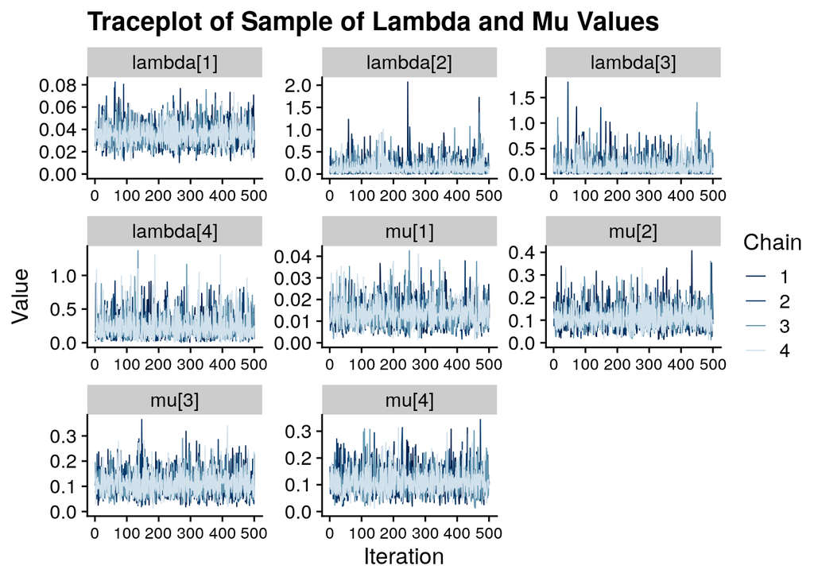

```r
parameter_subset <- c(
  "lambda[1]", "lambda[2]", "lambda[3]", "lambda[4]",
  "mu[1]",     "mu[2]",     "mu[3]",     "mu[4]"
  )

pnbd_long_fixed3_stanfit$draws(inc_warmup = FALSE) |>
  mcmc_trace(pars = parameter_subset) +
  expand_limits(y = 0) +
  labs(
    x = "Iteration",
    y = "Value",
    title = "Traceplot of Sample of Lambda and Mu Values"
    ) +
  theme(axis.text.x = element_text(size = 10))
```

We want to check the $N_{eff}$ statistics also.

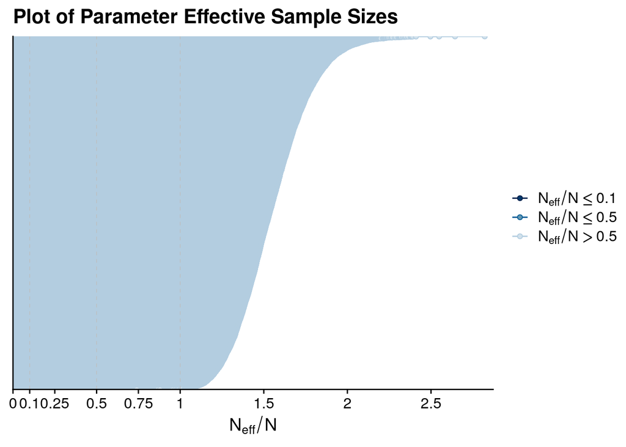

```r
pnbd_long_fixed3_stanfit |>
  neff_ratio(pars = c("lambda", "mu")) |>
  mcmc_neff() +
    ggtitle("Plot of Parameter Effective Sample Sizes")
```

## 4.2 Assess the Model

As we intend to run the same logic to assess each of our models, we have combined all this logic into a single function `run_model_assessment`, to run the simulations and combine the datasets.

```r
pnbd_stanfit <- pnbd_long_fixed3_stanfit |>
  recover_types(customer_fit_stats_tbl)

pnbd_long_fixed3_assess_data_lst <- run_model_assessment(
  model_stanfit       = pnbd_stanfit,
  insample_tbl        = customer_fit_subset_tbl,
  fit_label           = "pnbd_long_fixed3",
  fit_end_dttm        = use_fit_end_date     |> as.POSIXct(),
  valid_start_dttm    = use_valid_start_date |> as.POSIXct(),
  valid_end_dttm      = use_valid_end_date   |> as.POSIXct(),
  precompute_rootdir  = "precompute",
  data_dir            = "data",
  summary_include_tnx = FALSE,
  sim_seed            = 4230
  )

pnbd_long_fixed3_assess_data_lst |> glimpse()
```

```
List of 5
 $ model_fit_index_filepath     : 'glue' chr "data/pnbd_long_fixed3_assess_fit_index_tbl.rds"
 $ model_valid_index_filepath   : 'glue' chr "data/pnbd_long_fixed3_assess_valid_index_tbl.rds"
 $ model_simstats_filepath      : 'glue' chr "data/pnbd_long_fixed3_assess_model_simstats_tbl.rds"
 $ model_fit_simstats_filepath  : 'glue' chr "data/pnbd_long_fixed3_assess_fit_simstats_tbl.rds"
 $ model_valid_simstats_filepath: 'glue' chr "data/pnbd_long_fixed3_assess_valid_simstats_tbl.rds"
```

### 4.2.1 Check In-Sample Data Validation

We first check the model against the in-sample data.

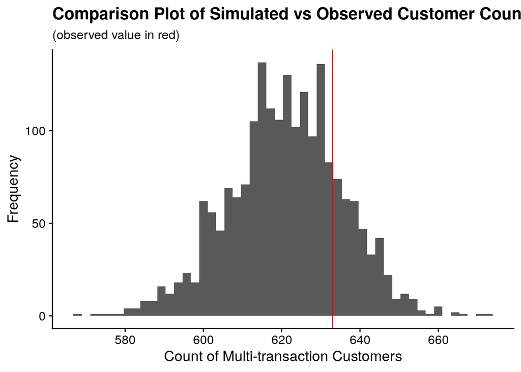

```r
simdata_tbl <- pnbd_long_fixed3_assess_data_lst |>
  use_series(model_fit_simstats_filepath) |>
  read_rds()

insample_plots_lst <- create_model_assessment_plots(
  obsdata_tbl = customer_fit_subset_tbl,
  simdata_tbl = simdata_tbl
  )

insample_plots_lst$multi_plot |> print()
```

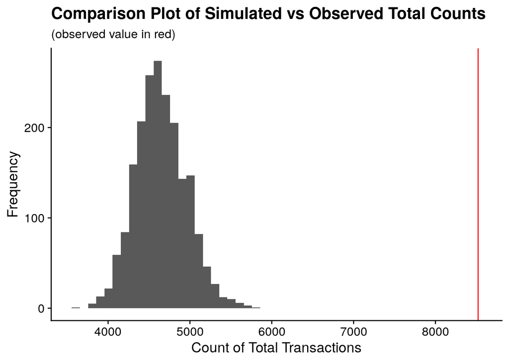

```r
insample_plots_lst$total_plot |> print()
```

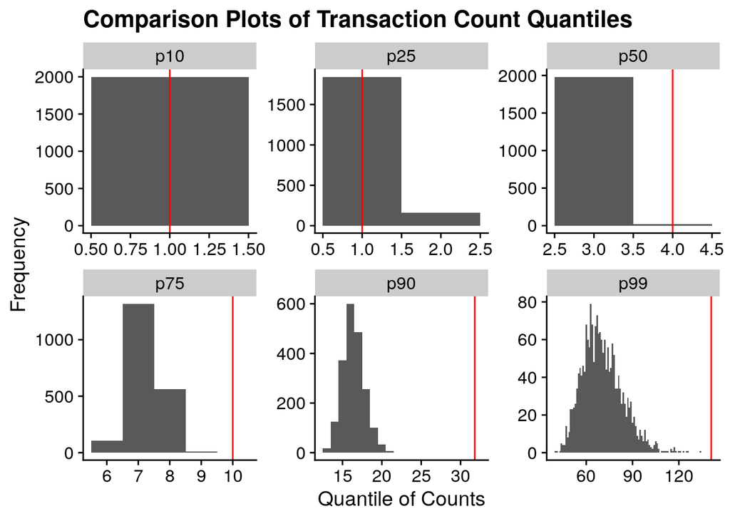

```r
insample_plots_lst$quant_plot |> print()
```

### 4.2.2 Check Out-of-Sample Data Validation

We now repeat for the out-of-sample data.

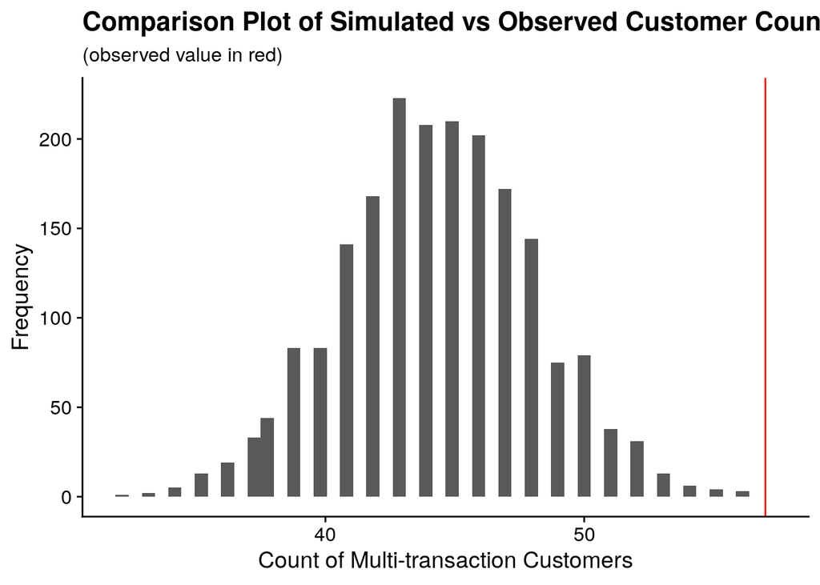

```r
simdata_tbl <- pnbd_long_fixed3_assess_data_lst |>
  use_series(model_valid_simstats_filepath) |>
  read_rds()

outsample_plots_lst <- create_model_assessment_plots(
  obsdata_tbl = customer_valid_subset_tbl,
  simdata_tbl = simdata_tbl
  )

outsample_plots_lst$multi_plot |> print()
```

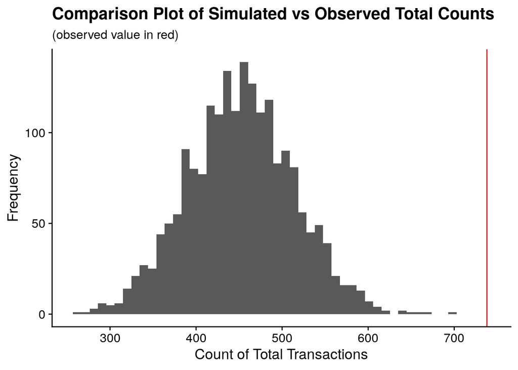

```r
outsample_plots_lst$total_plot |> print()
```

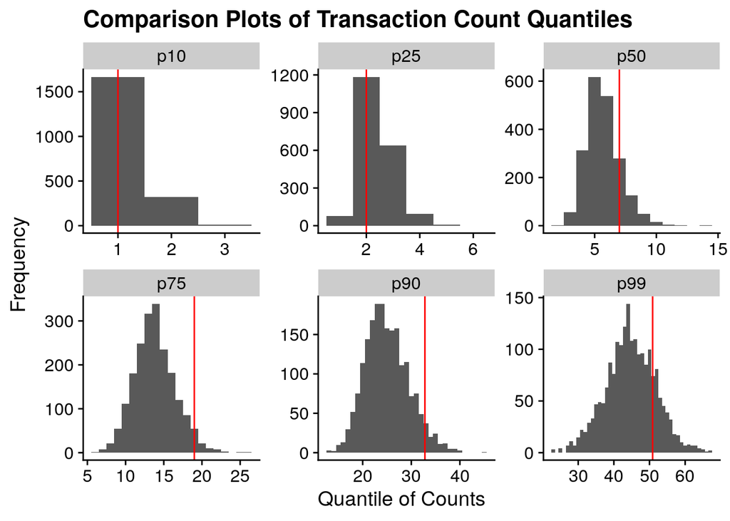

```r
outsample_plots_lst$quant_plot |> print()
```

# 5 Compare Model Outputs

We have looked at each of the models individually, but it is also worth looking at each of the models as a group.

```r
calculate_simulation_statistics <- function(file_rds) {
  simdata_tbl <- read_rds(file_rds)

  multicount_cust_tbl <- simdata_tbl |>
    filter(sim_tnx_count > 0) |>
    count(draw_id, name = "multicust_count")

  totaltnx_data_tbl <- simdata_tbl |>
    count(draw_id, wt = sim_tnx_count, name = "simtnx_count")

  simstats_tbl <- multicount_cust_tbl |>
    inner_join(totaltnx_data_tbl, by = "draw_id")

  return(simstats_tbl)
}
```

```r
obs_fit_customer_count <- obs_fitdata_tbl |>
  filter(tnx_count > 0) |>
  nrow()

obs_valid_customer_count <- obs_validdata_tbl |>
  filter(tnx_count > 0) |>
  nrow()

obs_fit_total_count <- obs_fitdata_tbl |>
  pull(tnx_count) |>
  sum()

obs_valid_total_count <- obs_validdata_tbl |>
  pull(tnx_count) |>
  sum()

obs_stats_tbl <- tribble(
  ~assess_type, ~name,               ~obs_value,
  "fit",        "multicust_count",   obs_fit_customer_count,
  "fit",        "simtnx_count",      obs_fit_total_count,
  "valid",      "multicust_count",   obs_valid_customer_count,
  "valid",      "simtnx_count",      obs_valid_total_count
  )

model_assess_tbl <- dir_ls("data", regexp = "pnbd_long_fixed.*_assess_.*simstats") |>
  enframe(name = NULL, value = "file_path") |>
  filter(str_detect(file_path, "_assess_model_", negate = TRUE)) |>
  mutate(
    model_label = str_replace(file_path, "data/pnbd_long_(fixed.*?)_assess_.*", "\\1"),
    assess_type = if_else(str_detect(file_path, "_assess_fit_"), "fit", "valid"),

    sim_data = map(
      file_path, calculate_simulation_statistics,

      .progress = "calculate_simulation_statistics"
      )
    )

model_assess_tbl |> glimpse()
```

```
Rows: 6
Columns: 4
$ file_path   <fs::path> "data/pnbd_long_fixed1_assess_fit_simstats_tbl.rds", …
$ model_label <chr> "fixed1", "fixed1", "fixed2", "fixed2", "fixed3", "fixed3"
$ assess_type <chr> "fit", "valid", "fit", "valid", "fit", "valid"
$ sim_data    <list> [<tbl_df[2000 x 3]>], [<tbl_df[2000 x 3]>], [<tbl_df[2000 …
```

```r
model_assess_summstat_tbl <- model_assess_tbl |>
  select(model_label, assess_type, sim_data) |>
  unnest(sim_data) |>
  pivot_longer(
    cols = !c(model_label, assess_type, draw_id)
    ) |>
  group_by(model_label, assess_type, name) |>
  summarise(
    .groups = "drop",

    mean_val = mean(value),
    p10 = quantile(value, 0.10),
    p25 = quantile(value, 0.25),
    p50 = quantile(value, 0.50),
    p75 = quantile(value, 0.75),
    p90 = quantile(value, 0.90)
    )

model_assess_summstat_tbl |> glimpse()
```

```
Rows: 12
Columns: 9
$ model_label <chr> "fixed1", "fixed1", "fixed1", "fixed1", "fixed2", "fixed2"…
$ assess_type <chr> "fit", "fit", "valid", "valid", "fit", "fit", "valid", "va…
$ name        <chr> "multicust_count", "simtnx_count", "multicust_count", "sim…
$ mean_val    <dbl> 639.2355, 8441.8860, 58.1700, 733.4730, 701.0205, 4670.491…
$ p10         <dbl> 621.0, 7672.9, 53.0, 641.0, 683.9, 4299.9, 41.0, 367.0, 60…
$ p25         <dbl> 630.00, 7995.75, 56.00, 684.75, 692.00, 4462.00, 43.00, 40…
$ p50         <dbl> 639.0, 8425.5, 58.0, 733.5, 701.0, 4664.0, 45.0, 445.0, 62…
$ p75         <dbl> 649.00, 8859.00, 61.00, 783.00, 710.00, 4867.25, 48.00, 48…
$ p90         <dbl> 656.0, 9243.0, 63.0, 826.0, 720.0, 5071.0, 50.0, 518.0, 63…
```

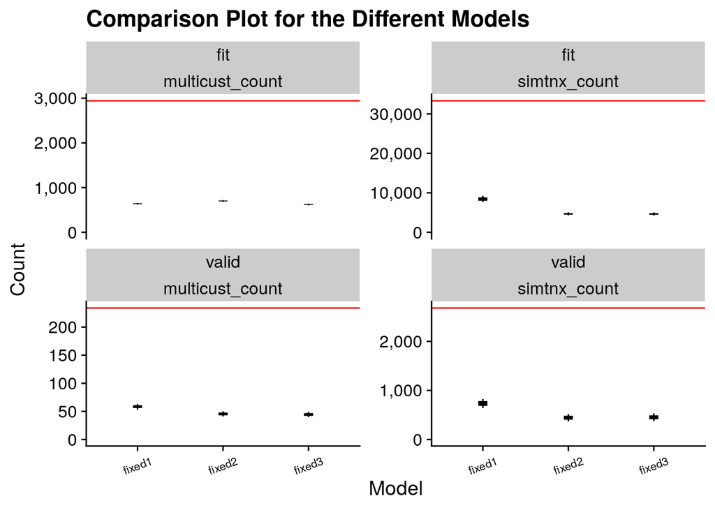

```r
#! echo: TRUE

ggplot(model_assess_summstat_tbl) +
  geom_errorbar(
    aes(x = model_label, ymin = p10, ymax = p90), width = 0
    ) +
  geom_errorbar(
    aes(x = model_label, ymin = p25, ymax = p75), width = 0, linewidth = 3
    ) +
  geom_hline(
    aes(yintercept = obs_value),
    data = obs_stats_tbl, colour = "red"
    ) +
  scale_y_continuous(labels = label_comma()) +
  expand_limits(y = 0) +
  facet_wrap(
    vars(assess_type, name), scale = "free_y"
    ) +
  labs(
    x = "Model",
    y = "Count",
    title = "Comparison Plot for the Different Models"
    ) +
  theme(
    axis.text.x = element_text(angle = 20, vjust = 0.5, size = 8)
    )
```

## 5.1 Write Assessment Data to Disk

We now want to save the assessment data to disk.

```r
model_assess_tbl |> write_rds("data/assess_data_pnbd_long_fixed_tbl.rds")
```

# R Environment

```r
options(width = 120L)
```

```r
options(width = 80L)
```